# IE 582 Homework 5

Deniz Turhan

3 Ocak 2019

**Musk Data** The task is transforming the data from instance-level to bag-level based on Multiple Instance Learning (MIL). To this aim, the data should be clustered firstly and then transforming to bag-level representation. Two distance measures are used namely Euclidean and Manhattan. Also, two different clustering algorithm are used for each distance measure: Pam (modified k-means) and Hierarchical. As the next step, lasso logistic regression model is trained for classifying the bags. For each bags created by clustering, a model is trained and the one with the best parameters is chosen. Lastly, 10-fold cross validation is done on the chosen model.

**Step 1**

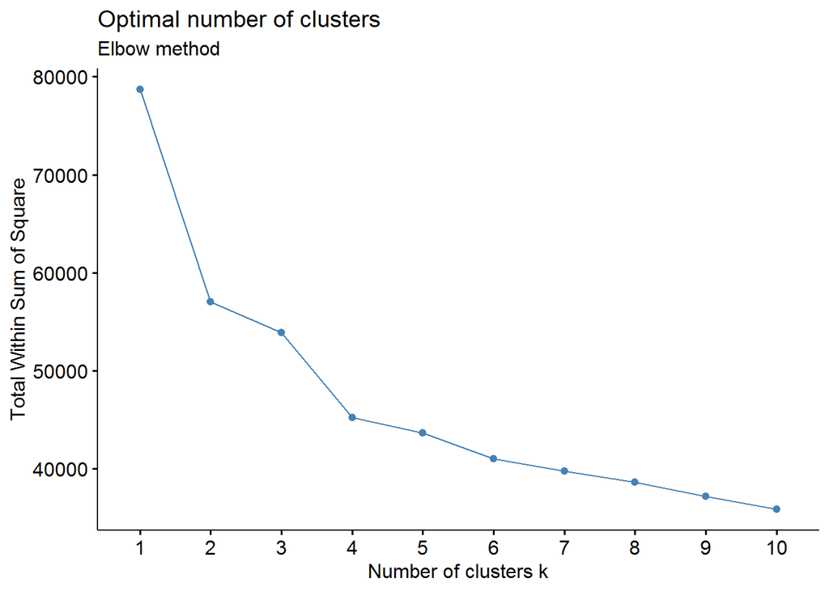

```r
setwd("C:/Users/casper/Downloads")
muskdata<-read.csv(file="Musk1.csv")
names(muskdata)[1]<-paste("bagclass")
names(muskdata)[2]<-paste("bagID")
muskdatamodel<-muskdata[,-(1:2)]
muskdatamodel <- scale(muskdatamodel)
set.seed(123)
# Elbow method 4
fviz_nbclust(muskdatamodel, pam, method = "wss") +

  labs(subtitle = "Elbow method")
```

```r
# # Silhouette method  2
# fviz_nbclust(muskdatamodel,pam, method = "silhouette")+
#   labs(subtitle = "Silhouette method")
# #gap statistic 10
# gap_stat <- clusGap(muskdatamodel, FUN = kmeans, nstart = 25,
#                     K.max = 10, B = 50)
# print(gap_stat, method = "firstmax")
# fviz_gap_stat(gap_stat)
#
# NbClust(data = muskdatamodel, diss = NULL, distance = "euclidean",
#         min.nc = 2, max.nc = 15, method = "kmeans")  #3

#number of cluster is chosen as 4
```

After data is scaled, number of clusters is determined by elbow method which takes sum of squared error as the measure. There are other methods such as silhoutte and gap statistics. I have chosen elbow method and number or clusters is taken 4.

```r
pameuc<-pam(muskdatamodel, 4, metric = "euclidean")
pamman<-pam(muskdatamodel, 4, metric = "manhattan")
hiareuc<-hclust(dist(muskdatamodel, method = "euclidean"))
clusters <- cutree(hiareuc, 4)
clust.centroid = function(i, dat, clusters) {
  ind = (clusters == i)
  colMeans(dat[ind,])
}
temp<-sapply(unique(clusters), clust.centroid,muskdatamodel, clusters)
medoids_hier<-as.data.frame(t(temp))
hiarman<-hclust(dist(muskdatamodel, method = "manhattan"))
clusters2 <- cutree(hiarman, 4)
clust.centroid2 = function(i, dat, clusters2) {
  ind = (clusters2 == i)
  colMeans(dat[ind,])
}
temp<-sapply(unique(clusters2), clust.centroid2,muskdatamodel, clusters2)
medoids_hier2<-as.data.frame(t(temp))

medoids_pam1<-as.data.frame(pameuc$medoids)
medoids_pam2<-as.data.frame(pamman$medoids)
```

The clusters are created by using euclidean and manhattan distances and the algorithms pam and hierarchical clustering. For the next step, the medoids of the clusters are kept.

**Step 2**

```r
distance1=data.frame()
distance2=data.frame()
distance3=data.frame()
distance4=data.frame()

for(i in 1:nrow(muskdatamodel)){
  for (j in 1:nrow(medoids_pam1)) {


 distance1[i,j]<-dist(rbind(medoids_pam1[j,],muskdatamodel[i,]))
 distance2[i,j]<-dist(rbind(medoids_pam2[j,],muskdatamodel[i,]))
 distance3[i,j]<-dist(rbind(medoids_hier[j,],muskdatamodel[i,]))
 distance4[i,j]<-dist(rbind(medoids_hier2[j,],muskdatamodel[i,]))
  }}

data1<-cbind(muskdata[,1:2],distance1)
data2<-cbind(muskdata[,1:2],distance2)
data3<-cbind(muskdata[,1:2],distance3)
data4<-cbind(muskdata[,1:2],distance4)

#for pameuc
bags<-data.frame()


for (i in 1:92) {


  data1a<-data1%>%filter(bagID==i)
  data1a<-data1a[,-2]
  for (j in 1:5) {


  bags[i,j]<-mean(data1a[,j])
}
}
#for pamman
bags2<-data.frame()


for (i in 1:92) {


  data2a<-data2%>%filter(bagID==i)
  data2a<-data2a[,-2]
  for (j in 1:5) {


    bags2[i,j]<-mean(data2a[,j])
  }
}

#for hiereuc
bags3<-data.frame()


for (i in 1:92) {


  data3a<-data3%>%filter(bagID==i)
  data3a<-data3a[,-2]
  for (j in 1:5) {


    bags3[i,j]<-mean(data3a[,j])
  }
}
#for hierman
bags4<-data.frame()


for (i in 1:92) {


  data4a<-data4%>%filter(bagID==i)
  data4a<-data4a[,-2]
  for (j in 1:5) {


    bags4[i,j]<-mean(data4a[,j])
  }}
```

Four bags are constructed by four models (2 distance measure x 2 clustering method). For each bag, the distance of its instances to each cluster medoid is calculated. Then, the bags are represented as the average of their instance distances to the cluster medoids.

**Lasso Logistic Regression**

```r
#for pameuc

lambda1 <- optL1(bags$V1, penalized = ~., data = bags[,-1],
                 fusedl = FALSE, minlambda1 = 0, maxlambda1 = 2,
                 fold = 10)
```

```
## lambda= 0.763932     12345678910cvl= -45.39586
## lambda= 1.236068     12345678910cvl= -45.26653
## lambda= 1.527864     12345678910cvl= -45.19969
## lambda= 1.708204     12345678910cvl= -45.16308
## lambda= 1.81966  12345678910cvl= -45.14218
## lambda= 1.888544     12345678910cvl= -45.12991
## lambda= 1.931116     12345678910cvl= -45.12257
## lambda= 1.957428     12345678910cvl= -45.11812
## lambda= 1.973689     12345678910cvl= -45.11541
## lambda= 1.983739     12345678910cvl= -45.11374
## lambda= 1.98995  12345678910cvl= -45.11272
## lambda= 1.993789     12345678910cvl= -45.11209
## lambda= 1.996161     12345678910cvl= -45.1117
## lambda= 1.997628     12345678910cvl= -45.11146
## lambda= 1.998534     12345678910cvl= -45.11131
## lambda= 1.999094     12345678910cvl= -45.11122
## lambda= 1.99944  12345678910cvl= -45.11117
## lambda= 1.999654     12345678910cvl= -45.11113
```

```r
pen <- penalized(bags$V1, penalized = ~., data = bags[,-1],
                 lambda1 = lambda1$lambda,
                 fusedl = FALSE)
```

[output not shown]

[output cut: 138 more lines]

[output not shown]

```r
lassopredict<-predict(pen,penalized=bags[,-1])


lassopredict[lassopredict>0.5]=1
lassopredict[lassopredict<=0.5]=0

confusion.matrix <- table(bags$V1, lassopredict)
print(confusion.matrix)
```

```
##    lassopredict
##      0  1
##   0 35 10
##   1  8 39
```

```r
accuracy.percent <- 100*sum(diag(confusion.matrix))/sum(confusion.matrix)
print(paste("accuracy1:",accuracy.percent,"%"))
```

```
## [1] "accuracy1: 80.4347826086957 %"
```

```r
#for pamman

lambda1 <- optL1(bags2$V1, penalized = ~., data = bags2[,-1],
                 fusedl = FALSE, minlambda1 = 0, maxlambda1 = 2,
                 fold = 10)
```

```
## lambda= 0.763932     12345678910cvl= -43.78738
## lambda= 1.236068     12345678910cvl= -43.46965
## lambda= 1.527864     12345678910cvl= -43.42252
## lambda= 1.502592     12345678910cvl= -43.42628
## lambda= 1.708204     12345678910cvl= -43.39728
## lambda= 1.81966  12345678910cvl= -43.38304
## lambda= 1.888544     12345678910cvl= -43.37476
## lambda= 1.931116     12345678910cvl= -43.36983
## lambda= 1.957428     12345678910cvl= -43.36685
## lambda= 1.973689     12345678910cvl= -43.36504
## lambda= 1.983739     12345678910cvl= -43.36394
## lambda= 1.98995  12345678910cvl= -43.36325
## lambda= 1.993789     12345678910cvl= -43.36284
## lambda= 1.996161     12345678910cvl= -43.36258
## lambda= 1.997628     12345678910cvl= -43.36242
## lambda= 1.998534     12345678910cvl= -43.3623
## lambda= 1.999094     12345678910cvl= -43.36227
## lambda= 1.999267     12345678910cvl= -43.36224
## lambda= 1.999547     12345678910cvl= -43.36221
```

```r
pen <- penalized(bags2$V1, penalized = ~., data = bags2[,-1],
                 lambda1 = lambda1$lambda,
                 fusedl = FALSE)
```

[output not shown]

[output cut: 334 more lines]

[output not shown]

```r
lassopredict2<-predict(pen,penalized=bags2[,-1])


lassopredict2[lassopredict2>0.5]=1
lassopredict2[lassopredict2<=0.5]=0

confusion.matrix <- table(bags2$V1, lassopredict2)
print(confusion.matrix)
```

```
##    lassopredict2
##      0  1
##   0 33 12
##   1  9 38
```

```r
accuracy.percent <- 100*sum(diag(confusion.matrix))/sum(confusion.matrix)
print(paste("accuracy2:",accuracy.percent,"%"))
```

```
## [1] "accuracy2: 77.1739130434783 %"
```

```r
#for hiereuc

lambda1 <- optL1(bags3$V1, penalized = ~., data = bags3[,-1],
                 fusedl = FALSE, minlambda1 = 0, maxlambda1 = 2,
                 fold = 10)
```

```
## lambda= 0.763932     12345678910cvl= -50.37332
## lambda= 1.236068     12345678910cvl= -50.19312
## lambda= 1.527864     12345678910cvl= -50.08375
## lambda= 1.708204     12345678910cvl= -50.01719
## lambda= 1.81966  12345678910cvl= -49.97929
## lambda= 1.888544     12345678910cvl= -49.95681
## lambda= 1.931116     12345678910cvl= -49.94308
## lambda= 1.957428     12345678910cvl= -49.93474
## lambda= 1.973689     12345678910cvl= -49.92963
## lambda= 1.983739     12345678910cvl= -49.92649
## lambda= 1.98995  12345678910cvl= -49.92456
## lambda= 1.993789     12345678910cvl= -49.92337
## lambda= 1.996161     12345678910cvl= -49.92264
## lambda= 1.997628     12345678910cvl= -49.92218
## lambda= 1.998534     12345678910cvl= -49.9219
## lambda= 1.999094     12345678910cvl= -49.92172
## lambda= 1.99944  12345678910cvl= -49.92162
## lambda= 1.999654     12345678910cvl= -49.92155
```

```r
pen <- penalized(bags3$V1, penalized = ~., data = bags3[,-1],
                 lambda1 = lambda1$lambda,
                 fusedl = FALSE)
```

[output not shown]

```r
lassopredict3<-predict(pen,penalized=bags3[,-1])


lassopredict3[lassopredict3>0.5]=1
lassopredict3[lassopredict3<=0.5]=0

confusion.matrix <- table(bags3$V1, lassopredict3)
print(confusion.matrix)
```

```
##    lassopredict3
##      0  1
##   0 29 16
##   1 11 36
```

```r
accuracy.percent <- 100*sum(diag(confusion.matrix))/sum(confusion.matrix)
print(paste("accuracy3:",accuracy.percent,"%"))
```

```
## [1] "accuracy3: 70.6521739130435 %"
```

```r
#for hierman

lambda1 <- optL1(bags4$V1, penalized = ~., data = bags4[,-1],
                 fusedl = FALSE, minlambda1 = 0, maxlambda1 = 2,
                 fold = 10)
```

```
## lambda= 0.763932     12345678910cvl= -55.62875
## lambda= 1.236068     12345678910cvl= -55.53485
## lambda= 1.527864     12345678910cvl= -55.46463
## lambda= 1.708204     12345678910cvl= -55.42895
## lambda= 1.81966  12345678910cvl= -55.41075
## lambda= 1.888544     12345678910cvl= -55.40094
## lambda= 1.931116     12345678910cvl= -55.3954
## lambda= 1.957428     12345678910cvl= -55.39218
## lambda= 1.973689     12345678910cvl= -55.39027
## lambda= 1.983739     12345678910cvl= -55.38912
## lambda= 1.98995  12345678910cvl= -55.38842
## lambda= 1.993789     12345678910cvl= -55.38799
## lambda= 1.996161     12345678910cvl= -55.38772
## lambda= 1.997628     12345678910cvl= -55.38756
## lambda= 1.998534     12345678910cvl= -55.38746
## lambda= 1.999094     12345678910cvl= -55.38744
## lambda= 1.999172     12345678910cvl= -55.38739
## lambda= 1.999488     12345678910cvl= -55.38738
## lambda= 1.999586     12345678910cvl= -55.38734
```

```r
pen <- penalized(bags4$V1, penalized = ~., data = bags4[,-1],
                 lambda1 = lambda1$lambda,
                 fusedl = FALSE)
```

[output not shown]

[output cut: 244 more lines]

[output not shown]

```r
lassopredict4<-predict(pen,penalized=bags4[,-1])


lassopredict4[lassopredict4>0.5]=1
lassopredict4[lassopredict4<=0.5]=0

confusion.matrix <- table(bags4$V1, lassopredict4)
print(confusion.matrix)
```

```
##    lassopredict4
##      0  1
##   0 27 18
##   1 13 34
```

```r
accuracy.percent <- 100*sum(diag(confusion.matrix))/sum(confusion.matrix)
print(paste("accuracy4:",accuracy.percent,"%"))
```

```
## [1] "accuracy4: 66.304347826087 %"
```

Lasso logistic regression is trained on each bag. When the accuracies are checked, the best model is chosen as the one with pam clustering and euclidean distance with the number of clusters of 4. The accuracy is obtained as 80.43%.

```
## lambda= 0.763932     12345678910cvl= -39.76244
## lambda= 1.236068     12345678910cvl= -39.64138
## lambda= 1.527864     12345678910cvl= -39.58131
## lambda= 1.708204     12345678910cvl= -39.5494
## lambda= 1.81966  12345678910cvl= -39.53157
## lambda= 1.888544     12345678910cvl= -39.52126
## lambda= 1.931116     12345678910cvl= -39.51516
## lambda= 1.957428     12345678910cvl= -39.51148
## lambda= 1.973689     12345678910cvl= -39.50925
## lambda= 1.983739     12345678910cvl= -39.50788
## lambda= 1.98995  12345678910cvl= -39.50704
## lambda= 1.993789     12345678910cvl= -39.50653
## lambda= 1.996161     12345678910cvl= -39.50621
## lambda= 1.997628     12345678910cvl= -39.50601
## lambda= 1.998534     12345678910cvl= -39.50589
## lambda= 1.999094     12345678910cvl= -39.50583
## lambda= 1.99944  12345678910cvl= -39.50577
## lambda= 1.999654     12345678910cvl= -39.50575
## # nonzero coefficients: 5

# nonzero coefficients: 5

# nonzero coefficients: 5

# nonzero coefficients: 5

# nonzero coefficients: 5

# nonzero coefficients: 5

# nonzero coefficients: 5

# nonzero coefficients: 5

# nonzero coefficients: 5

# nonzero coefficients: 5

# nonzero coefficients: 5

```

[output cut: 135 more lines]

```

# nonzero coefficients: 5

# nonzero coefficients: 5

# nonzero coefficients: 5

# nonzero coefficients: 5

# nonzero coefficients: 5
##    lassopredict
##     0 1
##   0 5 0
##   1 2 3
## [1] "accuracy1: 80 %"
```

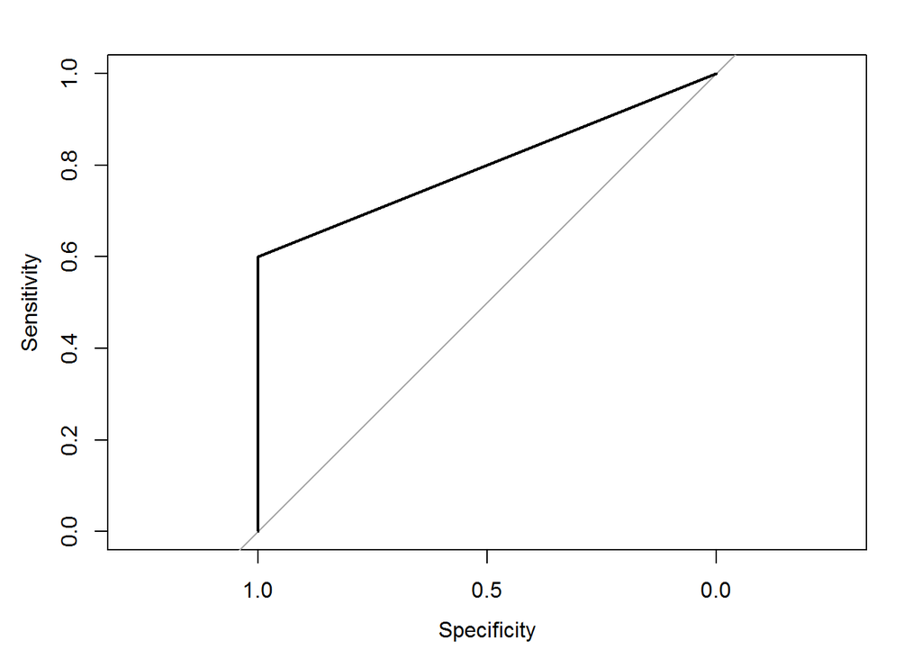

```
## lambda= 0.763932     12345678910cvl= -38.24609
## lambda= 1.236068     12345678910cvl= -38.04638
## lambda= 1.527864     12345678910cvl= -37.94463
## lambda= 1.708204     12345678910cvl= -37.88932
## lambda= 1.81966  12345678910cvl= -37.85786
## lambda= 1.888544     12345678910cvl= -37.83944
## lambda= 1.931116     12345678910cvl= -37.82842
## lambda= 1.957428     12345678910cvl= -37.82176
## lambda= 1.973689     12345678910cvl= -37.8177
## lambda= 1.983739     12345678910cvl= -37.81521
## lambda= 1.98995  12345678910cvl= -37.81368
## lambda= 1.993789     12345678910cvl= -37.81273
## lambda= 1.996161     12345678910cvl= -37.81215
## lambda= 1.997628     12345678910cvl= -37.81179
## lambda= 1.998534     12345678910cvl= -37.81157
## lambda= 1.999094     12345678910cvl= -37.81143
## lambda= 1.99944  12345678910cvl= -37.81135
## lambda= 1.999654     12345678910cvl= -37.8113
## # nonzero coefficients: 5

# nonzero coefficients: 5

# nonzero coefficients: 5

# nonzero coefficients: 5

# nonzero coefficients: 5

# nonzero coefficients: 5

# nonzero coefficients: 5

# nonzero coefficients: 5

# nonzero coefficients: 5

# nonzero coefficients: 5

# nonzero coefficients: 5

```

[output cut: 201 more lines]

```

# nonzero coefficients: 5

# nonzero coefficients: 5

# nonzero coefficients: 5

# nonzero coefficients: 5

# nonzero coefficients: 5
##    lassopredict
##     0 1
##   0 4 1
##   1 2 3
## [1] "accuracy1: 70 %"
```

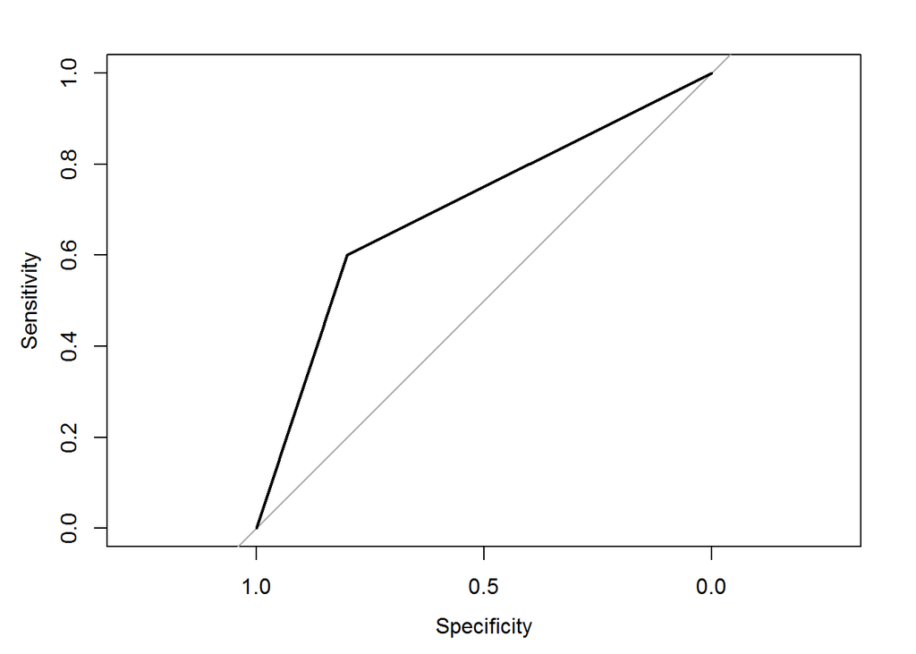

```
## lambda= 0.763932     12345678910cvl= -42.35285
## lambda= 1.236068     12345678910cvl= -42.20685
## lambda= 1.527864     12345678910cvl= -42.13389
## lambda= 1.708204     12345678910cvl= -42.09488
## lambda= 1.81966  12345678910cvl= -42.07299
## lambda= 1.888544     12345678910cvl= -42.06027
## lambda= 1.931116     12345678910cvl= -42.05272
## lambda= 1.957428     12345678910cvl= -42.04817
## lambda= 1.973689     12345678910cvl= -42.04541
## lambda= 1.983739     12345678910cvl= -42.04371
## lambda= 1.98995  12345678910cvl= -42.04267
## lambda= 1.993789     12345678910cvl= -42.04203
## lambda= 1.996161     12345678910cvl= -42.04164
## lambda= 1.997628     12345678910cvl= -42.04139
## lambda= 1.998534     12345678910cvl= -42.04124
## lambda= 1.999094     12345678910cvl= -42.04115
## lambda= 1.99944  12345678910cvl= -42.04109
## lambda= 1.999654     12345678910cvl= -42.04106
## # nonzero coefficients: 5

# nonzero coefficients: 5

# nonzero coefficients: 5

# nonzero coefficients: 5

# nonzero coefficients: 5

# nonzero coefficients: 5

# nonzero coefficients: 5

# nonzero coefficients: 5

# nonzero coefficients: 5

# nonzero coefficients: 5

# nonzero coefficients: 5

```

[output cut: 111 more lines]

```

# nonzero coefficients: 5

# nonzero coefficients: 5

# nonzero coefficients: 5

# nonzero coefficients: 5

# nonzero coefficients: 5
##    lassopredict
##     0 1
##   0 4 0
##   1 3 2
## [1] "accuracy1: 66.6666666666667 %"
```

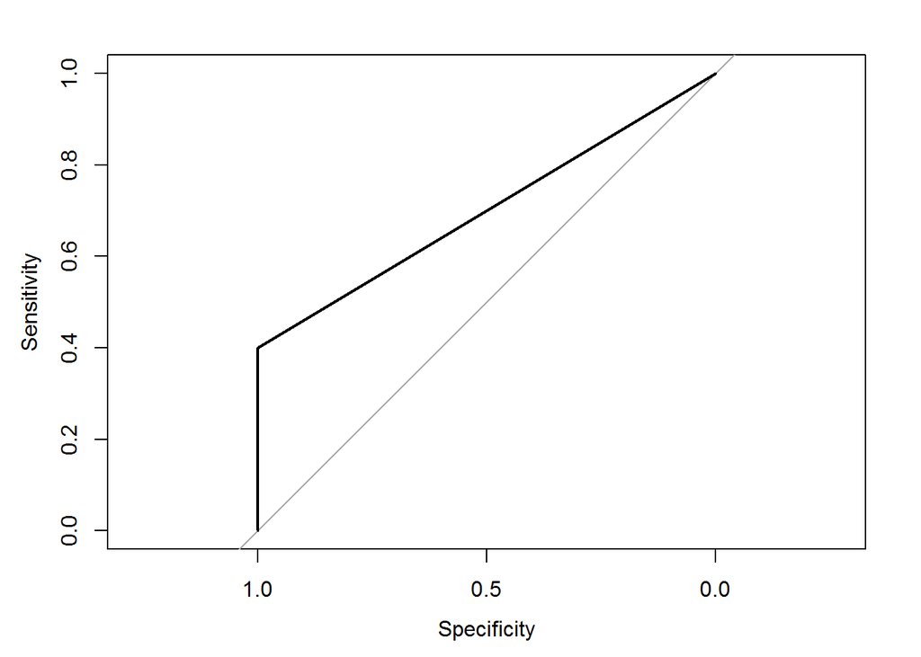

```
## lambda= 0.763932     12345678910cvl= -45.15891
## lambda= 1.236068     12345678910cvl= -44.93082
## lambda= 1.527864     12345678910cvl= -44.80869
## lambda= 1.708204     12345678910cvl= -44.73986
## lambda= 1.81966  12345678910cvl= -44.69975
## lambda= 1.888544     12345678910cvl= -44.67586
## lambda= 1.931116     12345678910cvl= -44.66143
## lambda= 1.957428     12345678910cvl= -44.65264
## lambda= 1.973689     12345678910cvl= -44.64725
## lambda= 1.983739     12345678910cvl= -44.64395
## lambda= 1.98995  12345678910cvl= -44.64191
## lambda= 1.993789     12345678910cvl= -44.64065
## lambda= 1.996161     12345678910cvl= -44.63987
## lambda= 1.997628     12345678910cvl= -44.6394
## lambda= 1.998534     12345678910cvl= -44.6391
## lambda= 1.999094     12345678910cvl= -44.63892
## lambda= 1.99944  12345678910cvl= -44.6388
## lambda= 1.999654     12345678910cvl= -44.63873
## # nonzero coefficients: 5

# nonzero coefficients: 5

# nonzero coefficients: 5

# nonzero coefficients: 5

# nonzero coefficients: 5

# nonzero coefficients: 5

# nonzero coefficients: 5

# nonzero coefficients: 5

# nonzero coefficients: 5

# nonzero coefficients: 5

# nonzero coefficients: 5

```

[output cut: 145 more lines]

```

# nonzero coefficients: 5

# nonzero coefficients: 5

# nonzero coefficients: 5

# nonzero coefficients: 5

# nonzero coefficients: 5
##    lassopredict
##     0 1
##   0 4 0
##   1 0 5
## [1] "accuracy1: 100 %"
```

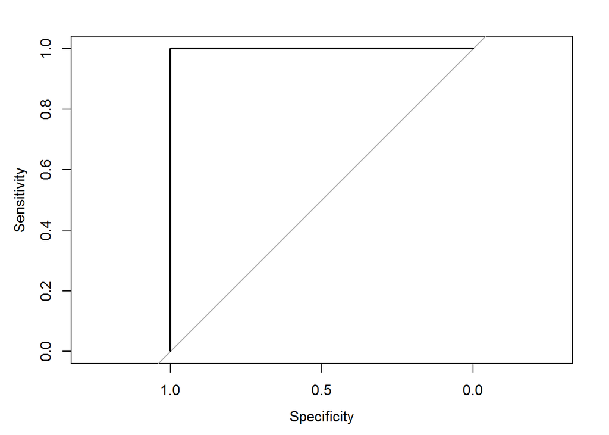

```
## lambda= 0.763932     12345678910cvl= -42.05464
## lambda= 1.236068     12345678910cvl= -41.95532
## lambda= 1.527864     12345678910cvl= -41.9069
## lambda= 1.708204     12345678910cvl= -41.8816
## lambda= 1.81966  12345678910cvl= -41.86767
## lambda= 1.888544     12345678910cvl= -41.85969
## lambda= 1.931116     12345678910cvl= -41.855
## lambda= 1.957428     12345678910cvl= -41.85219
## lambda= 1.973689     12345678910cvl= -41.85048
## lambda= 1.983739     12345678910cvl= -41.84944
## lambda= 1.98995  12345678910cvl= -41.84881
## lambda= 1.993789     12345678910cvl= -41.84841
## lambda= 1.996161     12345678910cvl= -41.84817
## lambda= 1.997628     12345678910cvl= -41.84802
## lambda= 1.998534     12345678910cvl= -41.84793
## lambda= 1.999094     12345678910cvl= -41.84787
## lambda= 1.99944  12345678910cvl= -41.84784
## lambda= 1.999654     12345678910cvl= -41.84782
## # nonzero coefficients: 5

# nonzero coefficients: 5

# nonzero coefficients: 5

# nonzero coefficients: 5

# nonzero coefficients: 5

# nonzero coefficients: 5

# nonzero coefficients: 5

# nonzero coefficients: 5

# nonzero coefficients: 5

# nonzero coefficients: 5

# nonzero coefficients: 5

```

[output cut: 141 more lines]

```

# nonzero coefficients: 5

# nonzero coefficients: 5

# nonzero coefficients: 5

# nonzero coefficients: 5

# nonzero coefficients: 5
##    lassopredict
##     0 1
##   0 2 2
##   1 0 5
## [1] "accuracy1: 77.7777777777778 %"
```

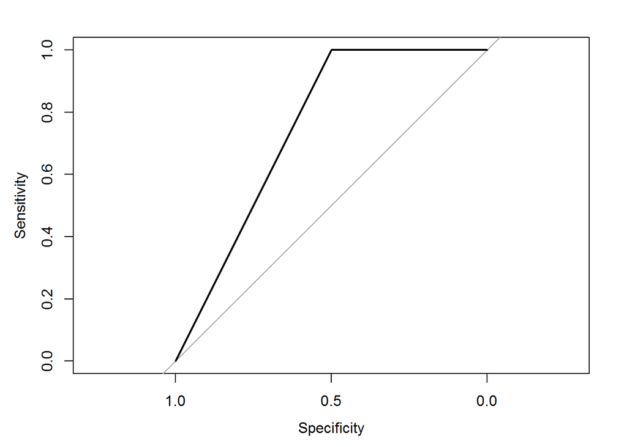

```
## lambda= 0.763932     12345678910cvl= -38.87783
## lambda= 1.236068     12345678910cvl= -38.75066
## lambda= 1.527864     12345678910cvl= -38.69096
## lambda= 1.708204     12345678910cvl= -38.66064
## lambda= 1.81966  12345678910cvl= -38.64428
## lambda= 1.888544     12345678910cvl= -38.63504
## lambda= 1.931116     12345678910cvl= -38.62966
## lambda= 1.957428     12345678910cvl= -38.62646
## lambda= 1.973689     12345678910cvl= -38.62453
## lambda= 1.983739     12345678910cvl= -38.62335
## lambda= 1.98995  12345678910cvl= -38.62263
## lambda= 1.993789     12345678910cvl= -38.62219
## lambda= 1.996161     12345678910cvl= -38.62192
## lambda= 1.997628     12345678910cvl= -38.62175
## lambda= 1.998534     12345678910cvl= -38.62165
## lambda= 1.999094     12345678910cvl= -38.62158
## lambda= 1.99944  12345678910cvl= -38.62154
## lambda= 1.999654     12345678910cvl= -38.62152
## # nonzero coefficients: 5

# nonzero coefficients: 5

# nonzero coefficients: 5

# nonzero coefficients: 5

# nonzero coefficients: 5

# nonzero coefficients: 5

# nonzero coefficients: 5

# nonzero coefficients: 5

# nonzero coefficients: 5

# nonzero coefficients: 5

# nonzero coefficients: 5

```

[output cut: 141 more lines]

```

# nonzero coefficients: 5

# nonzero coefficients: 5

# nonzero coefficients: 5

# nonzero coefficients: 5

# nonzero coefficients: 5
##    lassopredict
##     0 1
##   0 3 1
##   1 1 4
## [1] "accuracy1: 77.7777777777778 %"
```

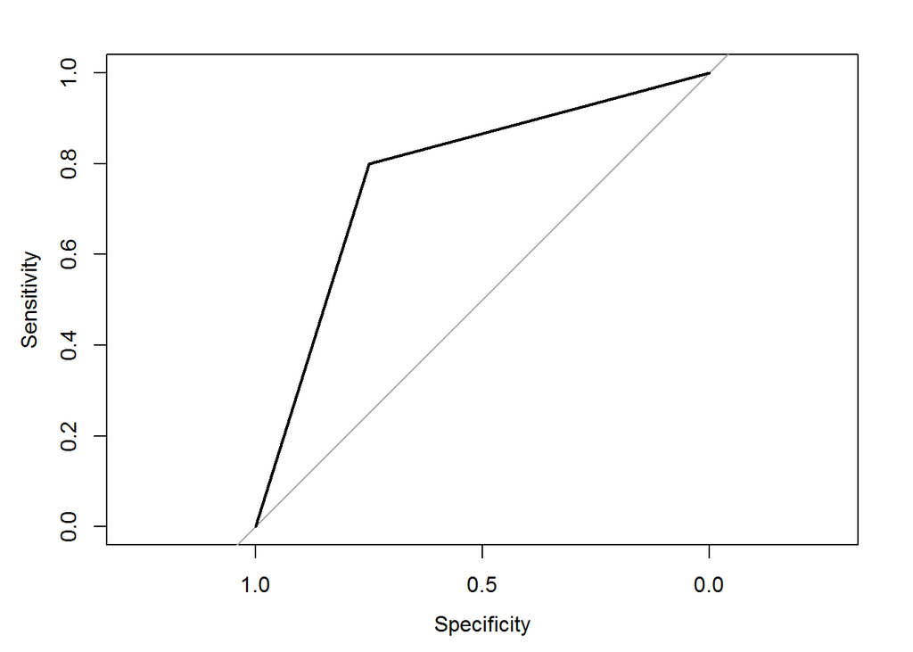

```
## lambda= 0.763932     12345678910cvl= -41.4627
## lambda= 1.236068     12345678910cvl= -41.32318
## lambda= 1.527864     12345678910cvl= -41.25241
## lambda= 1.708204     12345678910cvl= -41.21415
## lambda= 1.81966  12345678910cvl= -41.19251
## lambda= 1.888544     12345678910cvl= -41.17988
## lambda= 1.931116     12345678910cvl= -41.17235
## lambda= 1.957428     12345678910cvl= -41.16781
## lambda= 1.973689     12345678910cvl= -41.16504
## lambda= 1.983739     12345678910cvl= -41.16334
## lambda= 1.98995  12345678910cvl= -41.1623
## lambda= 1.993789     12345678910cvl= -41.16166
## lambda= 1.996161     12345678910cvl= -41.16126
## lambda= 1.997628     12345678910cvl= -41.16102
## lambda= 1.998534     12345678910cvl= -41.16086
## lambda= 1.999094     12345678910cvl= -41.16077
## lambda= 1.99944  12345678910cvl= -41.16071
## lambda= 1.999654     12345678910cvl= -41.16068
## # nonzero coefficients: 5

# nonzero coefficients: 5

# nonzero coefficients: 5

# nonzero coefficients: 5

# nonzero coefficients: 5

# nonzero coefficients: 5

# nonzero coefficients: 5

# nonzero coefficients: 5

# nonzero coefficients: 5

# nonzero coefficients: 5

# nonzero coefficients: 5

```

[output cut: 135 more lines]

```

# nonzero coefficients: 5

# nonzero coefficients: 5

# nonzero coefficients: 5

# nonzero coefficients: 5

# nonzero coefficients: 5
##    lassopredict
##     0 1
##   0 4 0
##   1 1 4
## [1] "accuracy1: 88.8888888888889 %"
```

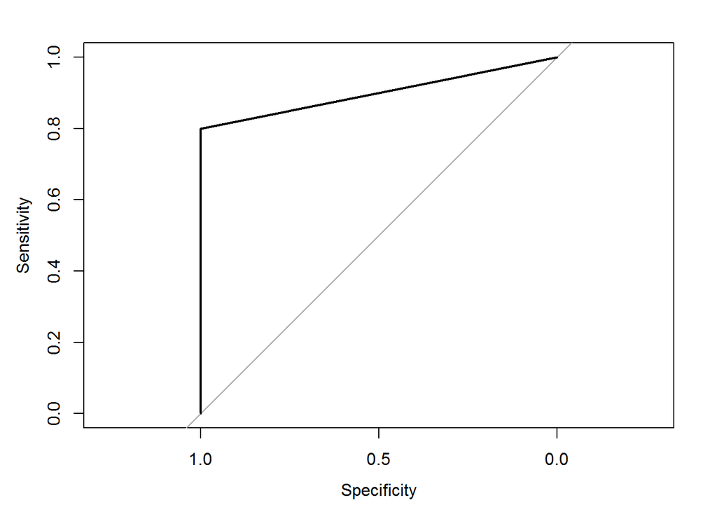

```
## lambda= 0.763932     12345678910cvl= -41.46301
## lambda= 1.236068     12345678910cvl= -41.32964
## lambda= 1.527864     12345678910cvl= -41.26261
## lambda= 1.708204     12345678910cvl= -41.22663
## lambda= 1.81966  12345678910cvl= -41.20639
## lambda= 1.888544     12345678910cvl= -41.19461
## lambda= 1.931116     12345678910cvl= -41.18762
## lambda= 1.957428     12345678910cvl= -41.1834
## lambda= 1.973689     12345678910cvl= -41.18083
## lambda= 1.983739     12345678910cvl= -41.17926
## lambda= 1.98995  12345678910cvl= -41.17829
## lambda= 1.993789     12345678910cvl= -41.1777
## lambda= 1.996161     12345678910cvl= -41.17733
## lambda= 1.997628     12345678910cvl= -41.17711
## lambda= 1.998534     12345678910cvl= -41.17697
## lambda= 1.999094     12345678910cvl= -41.17688
## lambda= 1.99944  12345678910cvl= -41.17683
## lambda= 1.999654     12345678910cvl= -41.1768
## # nonzero coefficients: 5

# nonzero coefficients: 5

# nonzero coefficients: 5

# nonzero coefficients: 5

# nonzero coefficients: 5

# nonzero coefficients: 5

# nonzero coefficients: 5

# nonzero coefficients: 5

# nonzero coefficients: 5

# nonzero coefficients: 5

# nonzero coefficients: 5

```

[output cut: 161 more lines]

```

# nonzero coefficients: 5

# nonzero coefficients: 5

# nonzero coefficients: 5

# nonzero coefficients: 5

# nonzero coefficients: 5
##    lassopredict
##     0 1
##   0 4 1
##   1 1 3
## [1] "accuracy1: 77.7777777777778 %"
```

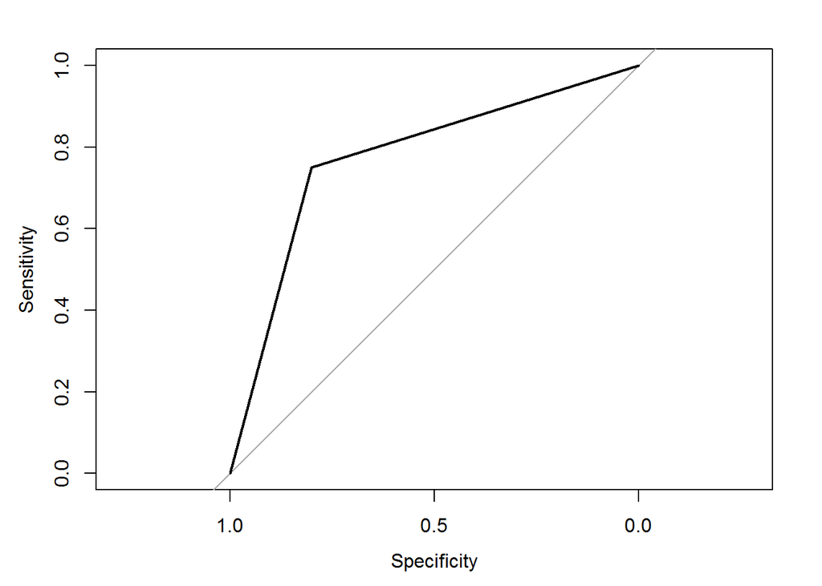

```
## lambda= 0.763932     12345678910cvl= -43.65624
## lambda= 1.236068     12345678910cvl= -43.47211
## lambda= 1.527864     12345678910cvl= -43.37577
## lambda= 1.708204     12345678910cvl= -43.32242
## lambda= 1.81966  12345678910cvl= -43.29172
## lambda= 1.888544     12345678910cvl= -43.27358
## lambda= 1.931116     12345678910cvl= -43.26269
## lambda= 1.957428     12345678910cvl= -43.25608
## lambda= 1.973689     12345678910cvl= -43.25204
## lambda= 1.983739     12345678910cvl= -43.24956
## lambda= 1.98995  12345678910cvl= -43.24804
## lambda= 1.993789     12345678910cvl= -43.2471
## lambda= 1.996161     12345678910cvl= -43.24651
## lambda= 1.997628     12345678910cvl= -43.24616
## lambda= 1.998534     12345678910cvl= -43.24594
## lambda= 1.999094     12345678910cvl= -43.2458
## lambda= 1.99944  12345678910cvl= -43.24571
## lambda= 1.999654     12345678910cvl= -43.24566
## # nonzero coefficients: 5

# nonzero coefficients: 5

# nonzero coefficients: 5

# nonzero coefficients: 5

# nonzero coefficients: 5

# nonzero coefficients: 5

# nonzero coefficients: 5

# nonzero coefficients: 5

# nonzero coefficients: 5

# nonzero coefficients: 5

# nonzero coefficients: 5

```

[output cut: 161 more lines]

```

# nonzero coefficients: 5

# nonzero coefficients: 5

# nonzero coefficients: 5

# nonzero coefficients: 5

# nonzero coefficients: 5
##    lassopredict
##     0 1
##   0 3 2
##   1 0 4
## [1] "accuracy1: 77.7777777777778 %"
```

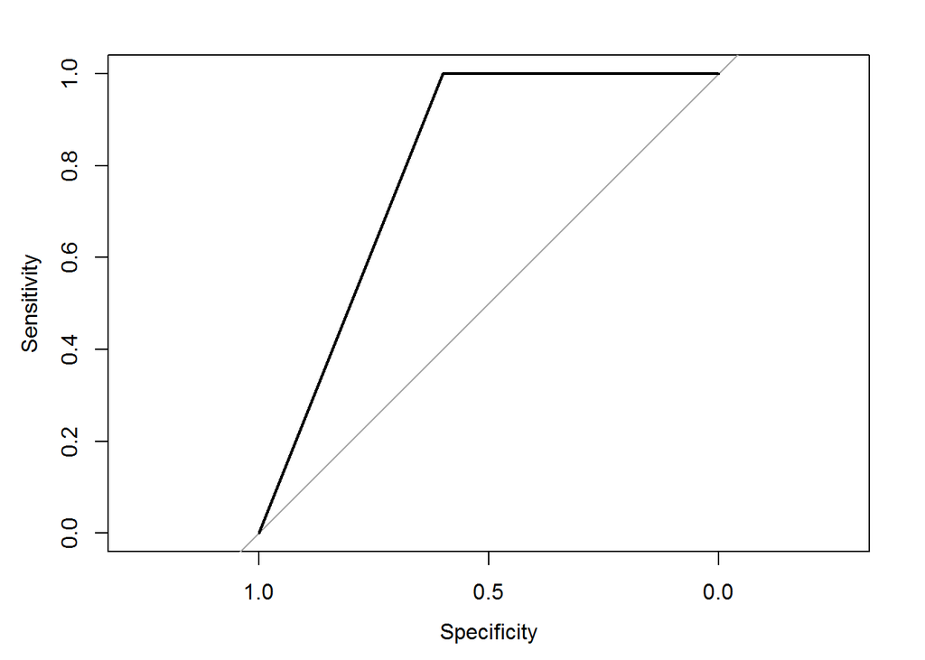

```
## lambda= 0.763932     12345678910cvl= -41.7796
## lambda= 1.236068     12345678910cvl= -41.60948
## lambda= 1.527864     12345678910cvl= -41.5256
## lambda= 1.708204     12345678910cvl= -41.48115
## lambda= 1.81966  12345678910cvl= -41.45635
## lambda= 1.888544     12345678910cvl= -41.44202
## lambda= 1.931116     12345678910cvl= -41.43352
## lambda= 1.957428     12345678910cvl= -41.42841
## lambda= 1.973689     12345678910cvl= -41.42531
## lambda= 1.983739     12345678910cvl= -41.42341
## lambda= 1.98995  12345678910cvl= -41.42224
## lambda= 1.993789     12345678910cvl= -41.42153
## lambda= 1.996161     12345678910cvl= -41.42108
## lambda= 1.997628     12345678910cvl= -41.42081
## lambda= 1.998534     12345678910cvl= -41.42064
## lambda= 1.999094     12345678910cvl= -41.42054
## lambda= 1.99944  12345678910cvl= -41.42047
## lambda= 1.999654     12345678910cvl= -41.42044
## # nonzero coefficients: 5

# nonzero coefficients: 5

# nonzero coefficients: 5

# nonzero coefficients: 5

# nonzero coefficients: 5

# nonzero coefficients: 5

# nonzero coefficients: 5

# nonzero coefficients: 5

# nonzero coefficients: 5

# nonzero coefficients: 5

# nonzero coefficients: 5

```

[output cut: 149 more lines]

```

# nonzero coefficients: 5

# nonzero coefficients: 5

# nonzero coefficients: 5

# nonzero coefficients: 5

# nonzero coefficients: 5
##    lassopredict
##     0 1
##   0 2 3
##   1 0 4
## [1] "accuracy1: 66.6666666666667 %"
```

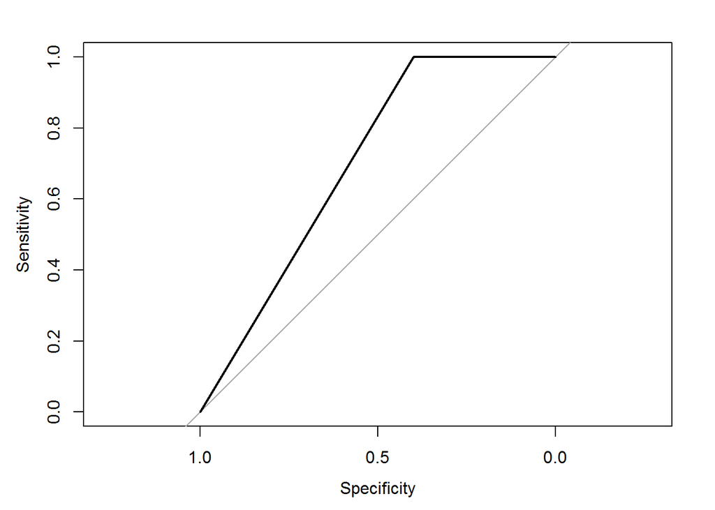

```r
#cross validation with the model
set.seed(123)
nofreplication=1
noffold=10
cvindices=generateCVRuns(bags$V1,ntimes=nofreplication,nfold=noffold,stratified=T)
firstIter=TRUE
for(k in 1:nofreplication){
  for(j in 1:noffold) {
    testindices=cvindices[[k]][[j]]
    lambda1 <- optL1(bags$V1[-testindices], penalized = ~., data = bags[-testindices,-1],
                     fusedl = FALSE, minlambda1 = 0, maxlambda1 = 2,
                     fold = 10)

    pen <- penalized(bags$V1[-testindices], penalized = ~., data = bags[-testindices,-1],
                     lambda1 = lambda1$lambda,
                     fusedl = FALSE)
    lassopredict<-predict(pen,penalized=bags[testindices,-1])


    lassopredict[lassopredict>0.5]=1
    lassopredict[lassopredict<=0.5]=0

    confusion.matrix <- table(bags$V1[testindices], lassopredict)
    print(confusion.matrix)
    accuracy.percent <- 100*sum(diag(confusion.matrix))/sum(confusion.matrix)
    print(paste("accuracy1:",accuracy.percent,"%"))
    a<-roc(bags$V1[testindices],lassopredict)
    roctut<-a$auc
    plot(a)
    #aggregation of results, if it is first iteration, initialize the data table
    if(firstIter){
      overallresults=data.table(Rep=k,Fold=j,Method="Lasso",Accuracy=accuracy.percent)
      overallroc=data.table(Rep=k,Fold=j,Method="Lasso",ROC=roctut)
      firstIter=FALSE
    } else {
      temp=data.table(Rep=k,Fold=j,Method="Lasso",Accuracy=accuracy.percent)
      overallresults=rbind(overallresults,temp)
      temp2=data.table(Rep=k,Fold=j,Method="Lasso",ROC=roctut)
      overallroc=rbind(overallroc,temp2)
    }
  }}
```

```r
overallresults
```

```
##     Rep Fold Method  Accuracy
##  1:   1    1  Lasso  80.00000
##  2:   1    2  Lasso  70.00000
##  3:   1    3  Lasso  66.66667
##  4:   1    4  Lasso 100.00000
##  5:   1    5  Lasso  77.77778
##  6:   1    6  Lasso  77.77778
##  7:   1    7  Lasso  88.88889
##  8:   1    8  Lasso  77.77778
##  9:   1    9  Lasso  77.77778
## 10:   1   10  Lasso  66.66667
```

```r
overallroc
```

```
##     Rep Fold Method   ROC
##  1:   1    1  Lasso 0.800
##  2:   1    2  Lasso 0.700
##  3:   1    3  Lasso 0.700
##  4:   1    4  Lasso 1.000
##  5:   1    5  Lasso 0.750
##  6:   1    6  Lasso 0.775
##  7:   1    7  Lasso 0.900
##  8:   1    8  Lasso 0.775
##  9:   1    9  Lasso 0.800
## 10:   1   10  Lasso 0.700
```

```r
crossvalaccuracy<-mean(overallresults$Accuracy)
print(paste("crossvalidationaccuracy:",crossvalaccuracy,"%"))
```

```
## [1] "crossvalidationaccuracy: 78.3333333333333 %"
```

```r
rocmean<-mean(overallroc$ROC)
print(paste("Rocaverage:",rocmean))
```

```
## [1] "Rocaverage: 0.79"
```

10-fold cross validation is done on the model chosen and cross validation accuracy is 78.33% . Similarly, ROC curve is plotted for each fold and on the average, AUC is 0.79.

**Appendix**

```r
library(factoextra)
library(NbClust)
library(cluster)
library(fastcluster)
library(stats)
library(dplyr)
library(penalized)
library(TunePareto)
library(data.table)
library(pROC)
setwd("C:/Users/casper/Downloads")
muskdata<-read.csv(file="Musk1.csv")
names(muskdata)[1]<-paste("bagclass")
names(muskdata)[2]<-paste("bagID")
muskdatamodel<-muskdata[,-(1:2)]
muskdatamodel <- scale(muskdatamodel)
set.seed(123)
# Elbow method 4
fviz_nbclust(muskdatamodel, pam, method = "wss") +

  labs(subtitle = "Elbow method")

# # Silhouette method  2
# fviz_nbclust(muskdatamodel,pam, method = "silhouette")+
#   labs(subtitle = "Silhouette method")
# #gap statistic 10
# gap_stat <- clusGap(muskdatamodel, FUN = kmeans, nstart = 25,
#                     K.max = 10, B = 50)
# print(gap_stat, method = "firstmax")
# fviz_gap_stat(gap_stat)
#
# NbClust(data = muskdatamodel, diss = NULL, distance = "euclidean",
#         min.nc = 2, max.nc = 15, method = "kmeans")  #3

#number of cluster is chosen as 4

pameuc<-pam(muskdatamodel, 4, metric = "euclidean")
pamman<-pam(muskdatamodel, 4, metric = "manhattan")
hiareuc<-hclust(dist(muskdatamodel, method = "euclidean"))
clusters <- cutree(hiareuc, 4)
clust.centroid = function(i, dat, clusters) {
  ind = (clusters == i)
  colMeans(dat[ind,])
}
temp<-sapply(unique(clusters), clust.centroid,muskdatamodel, clusters)
medoids_hier<-as.data.frame(t(temp))
hiarman<-hclust(dist(muskdatamodel, method = "manhattan"))
clusters2 <- cutree(hiarman, 4)
clust.centroid2 = function(i, dat, clusters2) {
  ind = (clusters2 == i)
  colMeans(dat[ind,])
}
temp<-sapply(unique(clusters2), clust.centroid2,muskdatamodel, clusters2)
medoids_hier2<-as.data.frame(t(temp))

medoids_pam1<-as.data.frame(pameuc$medoids)
medoids_pam2<-as.data.frame(pamman$medoids)

#Step 2

distance1=data.frame()
distance2=data.frame()
distance3=data.frame()
distance4=data.frame()

for(i in 1:nrow(muskdatamodel)){
  for (j in 1:nrow(medoids_pam1)) {


 distance1[i,j]<-dist(rbind(medoids_pam1[j,],muskdatamodel[i,]))
 distance2[i,j]<-dist(rbind(medoids_pam2[j,],muskdatamodel[i,]))
 distance3[i,j]<-dist(rbind(medoids_hier[j,],muskdatamodel[i,]))
 distance4[i,j]<-dist(rbind(medoids_hier2[j,],muskdatamodel[i,]))
  }}

data1<-cbind(muskdata[,1:2],distance1)
data2<-cbind(muskdata[,1:2],distance2)
data3<-cbind(muskdata[,1:2],distance3)
data4<-cbind(muskdata[,1:2],distance4)

#for pameuc
bags<-data.frame()


for (i in 1:92) {


  data1a<-data1%>%filter(bagID==i)
  data1a<-data1a[,-2]
  for (j in 1:5) {


  bags[i,j]<-mean(data1a[,j])
}
}
#for pamman
bags2<-data.frame()


for (i in 1:92) {


  data2a<-data2%>%filter(bagID==i)
  data2a<-data2a[,-2]
  for (j in 1:5) {


    bags2[i,j]<-mean(data2a[,j])
  }
}

#for hiereuc
bags3<-data.frame()


for (i in 1:92) {


  data3a<-data3%>%filter(bagID==i)
  data3a<-data3a[,-2]
  for (j in 1:5) {


    bags3[i,j]<-mean(data3a[,j])
  }
}
#for hierman
bags4<-data.frame()


for (i in 1:92) {


  data4a<-data4%>%filter(bagID==i)
  data4a<-data4a[,-2]
  for (j in 1:5) {


    bags4[i,j]<-mean(data4a[,j])
  }}
#lasso reg
#for pameuc

lambda1 <- optL1(bags$V1, penalized = ~., data = bags[,-1],
                 fusedl = FALSE, minlambda1 = 0, maxlambda1 = 2,
                 fold = 10)

pen <- penalized(bags$V1, penalized = ~., data = bags[,-1],
                 lambda1 = lambda1$lambda,
                 fusedl = FALSE)
lassopredict<-predict(pen,penalized=bags[,-1])


lassopredict[lassopredict>0.5]=1
lassopredict[lassopredict<=0.5]=0

confusion.matrix <- table(bags$V1, lassopredict)
print(confusion.matrix)
accuracy.percent <- 100*sum(diag(confusion.matrix))/sum(confusion.matrix)
print(paste("accuracy1:",accuracy.percent,"%"))

#for pamman

lambda1 <- optL1(bags2$V1, penalized = ~., data = bags2[,-1],
                 fusedl = FALSE, minlambda1 = 0, maxlambda1 = 2,
                 fold = 10)

pen <- penalized(bags2$V1, penalized = ~., data = bags2[,-1],
                 lambda1 = lambda1$lambda,
                 fusedl = FALSE)
lassopredict2<-predict(pen,penalized=bags2[,-1])


lassopredict2[lassopredict2>0.5]=1
lassopredict2[lassopredict2<=0.5]=0

confusion.matrix <- table(bags2$V1, lassopredict2)
print(confusion.matrix)
accuracy.percent <- 100*sum(diag(confusion.matrix))/sum(confusion.matrix)
print(paste("accuracy2:",accuracy.percent,"%"))
#for hiereuc

lambda1 <- optL1(bags3$V1, penalized = ~., data = bags3[,-1],
                 fusedl = FALSE, minlambda1 = 0, maxlambda1 = 2,
                 fold = 10)

pen <- penalized(bags3$V1, penalized = ~., data = bags3[,-1],
                 lambda1 = lambda1$lambda,
                 fusedl = FALSE)
lassopredict3<-predict(pen,penalized=bags3[,-1])


lassopredict3[lassopredict3>0.5]=1
lassopredict3[lassopredict3<=0.5]=0

confusion.matrix <- table(bags3$V1, lassopredict3)
print(confusion.matrix)
accuracy.percent <- 100*sum(diag(confusion.matrix))/sum(confusion.matrix)
print(paste("accuracy3:",accuracy.percent,"%"))
#for hierman

lambda1 <- optL1(bags4$V1, penalized = ~., data = bags4[,-1],
                 fusedl = FALSE, minlambda1 = 0, maxlambda1 = 2,
                 fold = 10)

pen <- penalized(bags4$V1, penalized = ~., data = bags4[,-1],
                 lambda1 = lambda1$lambda,
                 fusedl = FALSE)
lassopredict4<-predict(pen,penalized=bags4[,-1])


lassopredict4[lassopredict4>0.5]=1
lassopredict4[lassopredict4<=0.5]=0

confusion.matrix <- table(bags4$V1, lassopredict4)
print(confusion.matrix)
accuracy.percent <- 100*sum(diag(confusion.matrix))/sum(confusion.matrix)
print(paste("accuracy4:",accuracy.percent,"%"))


#the greatest accuracy is given by the pam clustering with euclidean distance

#cross validation with the model
set.seed(123)
nofreplication=1
noffold=10
cvindices=generateCVRuns(bags$V1,ntimes=nofreplication,nfold=noffold,stratified=T)
firstIter=TRUE
for(k in 1:nofreplication){
  for(j in 1:noffold) {
    testindices=cvindices[[k]][[j]]
    lambda1 <- optL1(bags$V1[-testindices], penalized = ~., data = bags[-testindices,-1],
                     fusedl = FALSE, minlambda1 = 0, maxlambda1 = 2,
                     fold = 10)

    pen <- penalized(bags$V1[-testindices], penalized = ~., data = bags[-testindices,-1],
                     lambda1 = lambda1$lambda,
                     fusedl = FALSE)
    lassopredict<-predict(pen,penalized=bags[testindices,-1])


    lassopredict[lassopredict>0.5]=1
    lassopredict[lassopredict<=0.5]=0

    confusion.matrix <- table(bags$V1[testindices], lassopredict)
    print(confusion.matrix)
    accuracy.percent <- 100*sum(diag(confusion.matrix))/sum(confusion.matrix)
    print(paste("accuracy1:",accuracy.percent,"%"))
    a<-roc(bags$V1[testindices],lassopredict)
    roctut<-a$auc
    plot(a)
    #aggregation of results, if it is first iteration, initialize the data table
    if(firstIter){
      overallresults=data.table(Rep=k,Fold=j,Method="Lasso",Accuracy=accuracy.percent)
      overallroc=data.table(Rep=k,Fold=j,Method="Lasso",ROC=roctut)
      firstIter=FALSE
    } else {
      temp=data.table(Rep=k,Fold=j,Method="Lasso",Accuracy=accuracy.percent)
      overallresults=rbind(overallresults,temp)
      temp2=data.table(Rep=k,Fold=j,Method="Lasso",ROC=roctut)
      overallroc=rbind(overallroc,temp2)
    }
  }}
overallresults
overallroc
crossvalaccuracy<-mean(overallresults$Accuracy)
print(paste("crossvalidationaccuracy:",crossvalaccuracy,"%"))
rocmean<-mean(overallroc$ROC)
print(paste("Rocaverage:",rocmean))
```